# Religious Gender Gap

Scott Claessens

2019-08-09

The purpose of this document is to conduct multilevel mediation models using brms.

# 0. Setup

Load the data.

```r
d <-
  readxl::read_xlsx("data/religionGender.xlsx", na = "NA") %>%
  select(CID, SITE, SEX, BGINT, PRAY, BGRIT, FORMALED, MMAT) %>%
  # create dummy for SEX
  mutate(female = ifelse(SEX=="Women",1,0)) %>%
  # remove extremes for beta distribution
  mutate(BGINT = ifelse(BGINT == 0, 0.0001, ifelse(BGINT == 1, 0.9999, BGINT))) %>%
  # PRAY and BGRIT are ordered factors
  mutate(PRAY  = factor(PRAY,   ordered = TRUE),
         BGRIT = factor(BGRIT,  ordered = TRUE)) %>%
  # standardise continuous variables
  mutate(FORMALED.std = scale(FORMALED)[,],
         MMAT.std     = scale(MMAT)[,])

d
```

| CID | SITE | SEX | BGINT | PRAY | BGRIT | FORMALED | MMAT | female | FORMALED.std | MMAT.std |
| --- | --- | --- | --- | --- | --- | --- | --- | --- | --- | --- |
| 1 | Co.Tanna | Women | 0.8750000 | NA | NA | 0 | 0.0000000 | 1 | -1.32376357 | -1.15364747 |
| 2 | Co.Tanna | Women | NA | NA | NA | 13 | 0.0000000 | 1 | 1.08875506 | -1.15364747 |
| 3 | Co.Tanna | Women | 0.9999000 | NA | NA | 0 | 0.2500000 | 1 | -1.32376357 | -0.58264410 |
| 4 | Co.Tanna | Women | 0.8750000 | NA | NA | 7 | 0.0000000 | 1 | -0.02471508 | -1.15364747 |
| 5 | Co.Tanna | Women | 0.8750000 | NA | NA | 14 | 0.0000000 | 1 | 1.27433342 | -1.15364747 |
| 6 | Co.Tanna | Women | 0.9999000 | NA | NA | 7 | 1.0000000 | 1 | -0.02471508 | 1.13036603 |
| 7 | Co.Tanna | Women | 0.9999000 | NA | NA | 12 | 0.7500000 | 1 | 0.90317670 | 0.55936266 |
| 8 | Co.Tanna | Women | 0.9999000 | NA | NA | 10 | 0.0000000 | 1 | 0.53201999 | -1.15364747 |
| 9 | Co.Tanna | Women | 0.9999000 | NA | NA | 6 | 0.2500000 | 1 | -0.21029343 | -0.58264410 |
| 10 | Co.Tanna | Women | 0.6250000 | NA | NA | 10 | 1.0000000 | 1 | 0.53201999 | 1.13036603 |

[output cut: 2193 more lines]

Tom would like to fit models of the following type to these data.

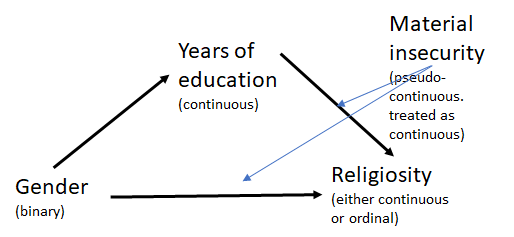

We conduct models in three stages: (1) direct effect only, (2) mediation, and (3) moderated mediation. We can later compare these using WAIC. We repeat this process for each religion variable.

# 1. BGINT

Retain complete cases.

```r
# n = 1864
d_temp <-
  d %>%
  select(SITE, BGINT, FORMALED.std, female, MMAT.std, SEX) %>%
  drop_na()
```

The religious variable `BGINT` is constrained between 0 and 1, so should not be treated as continuous. A Beta distribution should be used instead of a Gaussian (and WAIC shows the Beta distribution is superior with this outcome variable, I’ll leave that up to the reader).

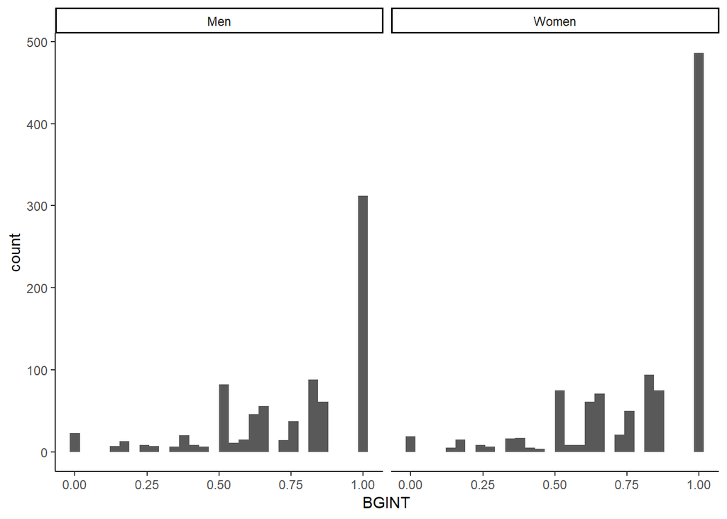

## 1.1. Direct effect only

```
##  Family: MV(beta, gaussian)
##   Links: mu = logit; phi = identity
##          mu = identity; sigma = identity
## Formula: BGINT ~ 1 + female + (1 | SITE)
##          FORMALED.std ~ 1 + (1 | SITE)
##    Data: d_temp (Number of observations: 1864)
## Samples: 4 chains, each with iter = 2000; warmup = 1000; thin = 1;
##          total post-warmup samples = 4000
##
## Group-Level Effects:
## ~SITE (Number of levels: 14)
##                           Estimate Est.Error l-95% CI u-95% CI Eff.Sample Rhat
## sd(BGINT_Intercept)           0.68      0.16     0.45     1.07        885 1.00
## sd(FORMALEDstd_Intercept)     0.90      0.20     0.60     1.39       1019 1.01
##
## Population-Level Effects:
##                       Estimate Est.Error l-95% CI u-95% CI Eff.Sample Rhat
## BGINT_Intercept           1.18      0.19     0.81     1.57       1240 1.00
## FORMALEDstd_Intercept     0.10      0.24    -0.37     0.61        910 1.00
## BGINT_female              0.10      0.06    -0.01     0.21       3766 1.00
##
## Family Specific Parameters:
##                   Estimate Est.Error l-95% CI u-95% CI Eff.Sample Rhat
## phi_BGINT             1.04      0.03     0.97     1.11       3767 1.00
## sigma_FORMALEDstd     0.64      0.01     0.62     0.66       3807 1.00
##
## Samples were drawn using sampling(NUTS). For each parameter, Eff.Sample
## is a crude measure of effective sample size, and Rhat is the potential
## scale reduction factor on split chains (at convergence, Rhat = 1).
```

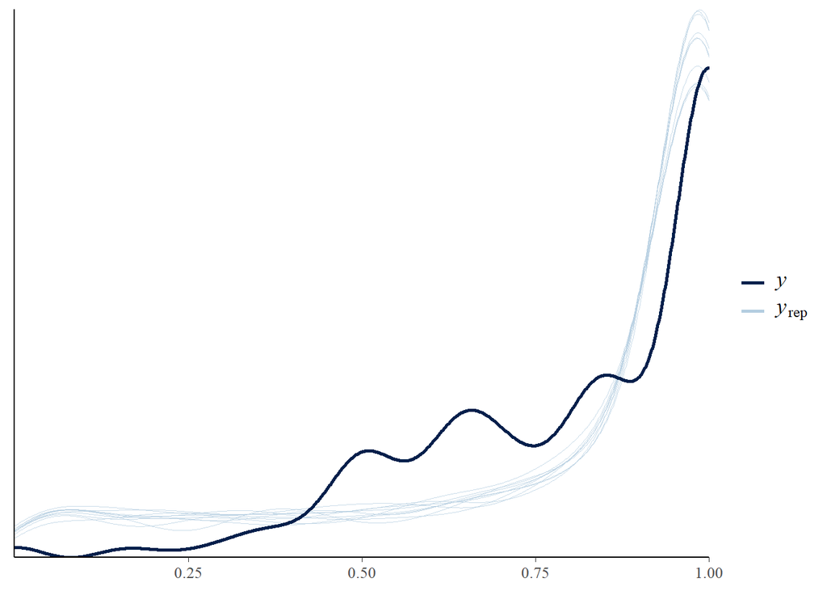

However, the parameter for `female` does not reliably lie above zero.

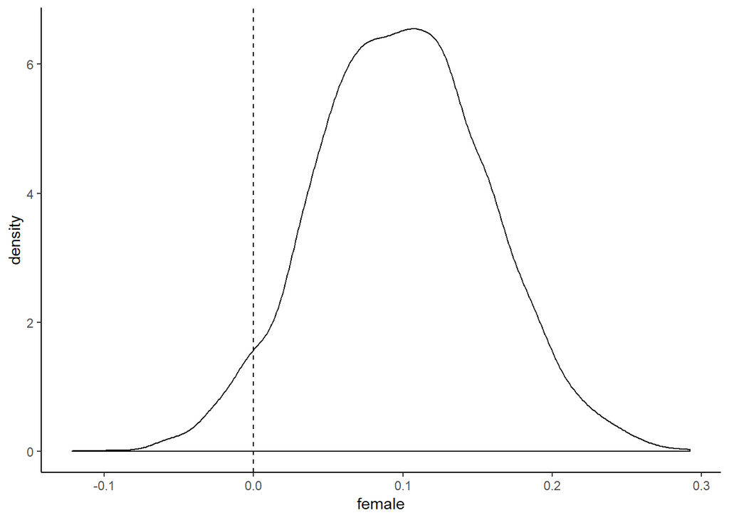

In line with this, model comparison (against a null random-intercept-only model) shows that including SEX improves the fit of the model, but not by much. Together, this suggests only a small direct effect of SEX for this outcome variable.

```
##                      WAIC     SE
## m1.1             -4512.92 277.93
## m1.1_null        -4512.63 278.10
## m1.1 - m1.1_null    -0.29   3.21
```

## 1.2. Mediation model

```
##  Family: MV(beta, gaussian)
##   Links: mu = logit; phi = identity
##          mu = identity; sigma = identity
## Formula: BGINT ~ 0 + intercept + female + FORMALED.std + (1 | SITE)
##          FORMALED.std ~ 0 + intercept + female + (1 | SITE)
##    Data: d_temp (Number of observations: 1864)
## Samples: 4 chains, each with iter = 2000; warmup = 1000; thin = 1;
##          total post-warmup samples = 4000
##
## Group-Level Effects:
## ~SITE (Number of levels: 14)
##                           Estimate Est.Error l-95% CI u-95% CI Eff.Sample Rhat
## sd(BGINT_Intercept)           0.66      0.16     0.44     1.05       1028 1.00
## sd(FORMALEDstd_Intercept)     0.91      0.21     0.60     1.41        847 1.00
##
## Population-Level Effects:
##                       Estimate Est.Error l-95% CI u-95% CI Eff.Sample Rhat
## BGINT_intercept           1.20      0.19     0.82     1.56       1240 1.00
## BGINT_female              0.09      0.06    -0.02     0.20       4218 1.00
## BGINT_FORMALED.std       -0.07      0.04    -0.16     0.01       3839 1.00
## FORMALEDstd_intercept     0.18      0.25    -0.29     0.65        953 1.00
## FORMALEDstd_female       -0.12      0.03    -0.18    -0.06       4351 1.00
##
## Family Specific Parameters:
##                   Estimate Est.Error l-95% CI u-95% CI Eff.Sample Rhat
## phi_BGINT             1.04      0.03     0.98     1.11       4813 1.00
## sigma_FORMALEDstd     0.64      0.01     0.62     0.66       4220 1.00
##
## Samples were drawn using sampling(NUTS). For each parameter, Eff.Sample
## is a crude measure of effective sample size, and Rhat is the potential
## scale reduction factor on split chains (at convergence, Rhat = 1).
```

We can draw this out for ease of interpretation. Stars represent 95% CIs outside zero.

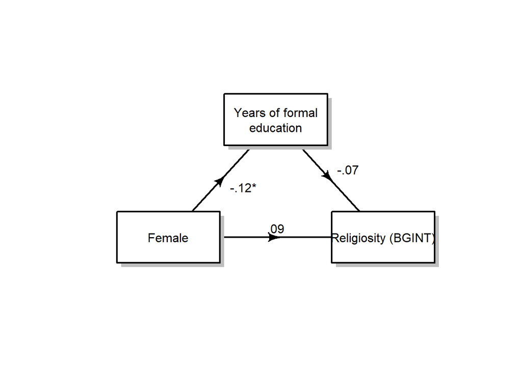

The direct effect decreases very slightly. There’s also a possible mediation pathway whereby females have fewer years of formal education, and those with fewer years of formal education are more likely to be religious (the two non-starred paths are very close to being ‘significant’, see model output).

Indeed, model comparison suggests that this mediation model is a better fit to the data than the direct effect alone.

```
##                 WAIC     SE
## m1.1        -4512.92 277.93
## m1.2        -4526.84 277.75
## m1.1 - m1.2    13.92   8.52
```

## 1.3. Moderated mediation model

Here, we treat the moderator `MAT.std` as a standardised continuous variable. However, from a histogram of the data, it seems to be an ordered categorical predictor (Tom did mention it was “pseudo-continuous”). Perhaps in the future we could use the `mo()` function to model monotonic effects.

```
##  Family: MV(beta, gaussian)
##   Links: mu = logit; phi = identity
##          mu = identity; sigma = identity
## Formula: BGINT ~ 0 + intercept + FORMALED.std * MMAT.std + female * MMAT.std + (1 | SITE)
##          FORMALED.std ~ 0 + intercept + female + (1 | SITE)
##    Data: d_temp (Number of observations: 1864)
## Samples: 4 chains, each with iter = 2000; warmup = 1000; thin = 1;
##          total post-warmup samples = 4000
##
## Group-Level Effects:
## ~SITE (Number of levels: 14)
##                           Estimate Est.Error l-95% CI u-95% CI Eff.Sample Rhat
## sd(BGINT_Intercept)           0.66      0.16     0.43     1.04       1289 1.00
## sd(FORMALEDstd_Intercept)     0.93      0.22     0.61     1.46       1085 1.00
##
## Population-Level Effects:
##                             Estimate Est.Error l-95% CI u-95% CI Eff.Sample Rhat
## BGINT_intercept                 1.20      0.19     0.80     1.57       1352 1.00
## BGINT_FORMALED.std             -0.07      0.04    -0.16     0.01       3752 1.00
## BGINT_MMAT.std                  0.02      0.05    -0.07     0.12       3775 1.00
## BGINT_female                    0.09      0.05    -0.02     0.20       4852 1.00
## BGINT_FORMALED.std:MMAT.std     0.02      0.03    -0.04     0.09       5375 1.00
## BGINT_MMAT.std:female          -0.01      0.06    -0.13     0.10       3777 1.00
## FORMALEDstd_intercept           0.17      0.26    -0.32     0.71        870 1.01
## FORMALEDstd_female             -0.12      0.03    -0.18    -0.06       5397 1.00
##
## Family Specific Parameters:
##                   Estimate Est.Error l-95% CI u-95% CI Eff.Sample Rhat
## phi_BGINT             1.04      0.03     0.97     1.11       4743 1.00
## sigma_FORMALEDstd     0.64      0.01     0.62     0.66       5297 1.00
##
## Samples were drawn using sampling(NUTS). For each parameter, Eff.Sample
## is a crude measure of effective sample size, and Rhat is the potential
## scale reduction factor on split chains (at convergence, Rhat = 1).
```

The lack of interaction effect with `MMAT.std` implies that material insecurity does not moderate this mediation. Does model comparison confirm this suspicion?

```r
compare_ic(m1.1, m1.2, m1.3, ic = "waic")
```

```
##                 WAIC     SE
## m1.1        -4512.92 277.93
## m1.2        -4526.84 277.75
## m1.3        -4522.49 277.79
## m1.1 - m1.2    13.92   8.52
## m1.1 - m1.3     9.57   9.06
## m1.2 - m1.3    -4.35   1.86
```

The model without the moderated mediation performs better.

# 2. PRAY

Retain complete cases.

```r
# n = 1155
d_temp <-
  d %>%
  select(SITE, PRAY, FORMALED.std, female, MMAT.std) %>%
  drop_na()
```

## 2.1. Direct effect only

The approach is the same with an ordinal outcome, except we change the model family from beta to cumulative.

```
##  Family: MV(cumulative, gaussian)
##   Links: mu = logit; disc = identity
##          mu = identity; sigma = identity
## Formula: PRAY ~ 1 + female + (1 | SITE)
##          FORMALED.std ~ 1 + (1 | SITE)
##    Data: d_temp (Number of observations: 1155)
## Samples: 4 chains, each with iter = 2000; warmup = 1000; thin = 1;
##          total post-warmup samples = 4000
##
## Group-Level Effects:
## ~SITE (Number of levels: 9)
##                           Estimate Est.Error l-95% CI u-95% CI Eff.Sample Rhat
## sd(PRAY_Intercept)            1.48      0.60     0.73     3.04       1244 1.00
## sd(FORMALEDstd_Intercept)     1.04      0.33     0.59     1.85       1093 1.00
##
## Population-Level Effects:
##                       Estimate Est.Error l-95% CI u-95% CI Eff.Sample Rhat
## PRAY_Intercept[1]        -3.50      0.56    -4.71    -2.40       1220 1.00
## PRAY_Intercept[2]        -2.74      0.56    -3.96    -1.66       1196 1.00
## PRAY_Intercept[3]        -2.14      0.55    -3.31    -1.07       1195 1.00
## PRAY_Intercept[4]        -0.77      0.55    -1.93     0.30       1185 1.00
## FORMALEDstd_Intercept    -0.10      0.37    -0.90     0.64       1100 1.00
## PRAY_female               0.41      0.13     0.15     0.67       5567 1.00
##
## Family Specific Parameters:
##                   Estimate Est.Error l-95% CI u-95% CI Eff.Sample Rhat
## sigma_FORMALEDstd     0.65      0.01     0.62     0.68       5323 1.00
##
## Samples were drawn using sampling(NUTS). For each parameter, Eff.Sample
## is a crude measure of effective sample size, and Rhat is the potential
## scale reduction factor on split chains (at convergence, Rhat = 1).
```

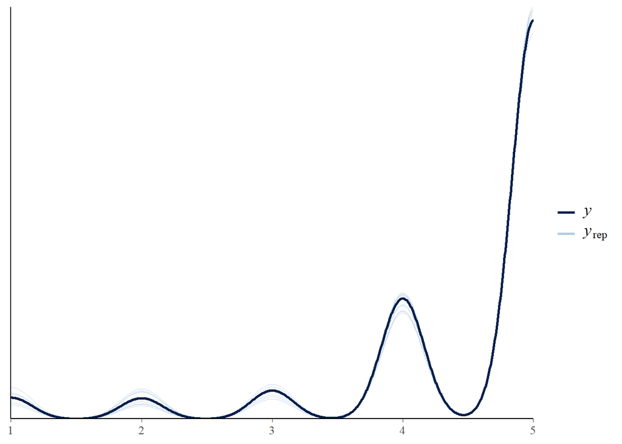

For this outcome variable, the parameter for `female` lies reliably above zero.

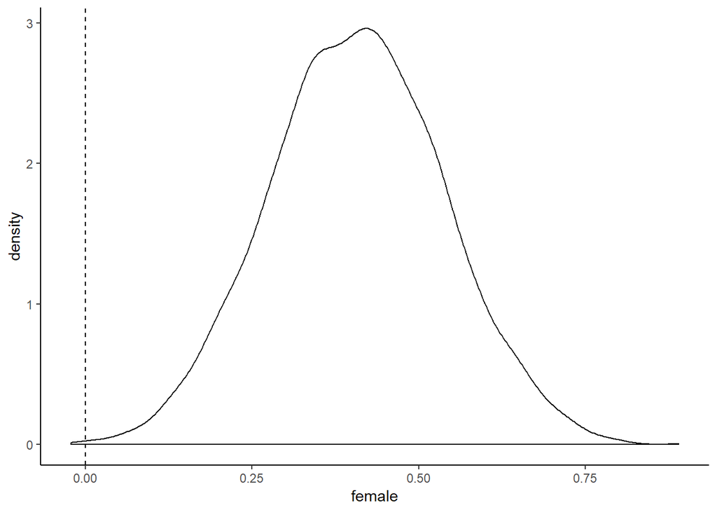

In line with this, model comparison (against a null random-intercept-only model) shows that including SEX improves the fit of the model (though there are wide standard errors).

```
##                     WAIC    SE
## m2.1             4419.15 93.47
## m2.1_null        4426.34 93.88
## m2.1 - m2.1_null   -7.19  6.20
```

## 2.2. Mediation model

```
##  Family: MV(cumulative, gaussian)
##   Links: mu = logit; disc = identity
##          mu = identity; sigma = identity
## Formula: PRAY ~ 1 + female + FORMALED.std + (1 | SITE)
##          FORMALED.std ~ 1 + female + (1 | SITE)
##    Data: d_temp (Number of observations: 1155)
## Samples: 4 chains, each with iter = 2000; warmup = 1000; thin = 1;
##          total post-warmup samples = 4000
##
## Group-Level Effects:
## ~SITE (Number of levels: 9)
##                           Estimate Est.Error l-95% CI u-95% CI Eff.Sample Rhat
## sd(PRAY_Intercept)            1.46      0.60     0.72     3.02        797 1.00
## sd(FORMALEDstd_Intercept)     1.03      0.33     0.60     1.82       1022 1.00
##
## Population-Level Effects:
##                       Estimate Est.Error l-95% CI u-95% CI Eff.Sample Rhat
## PRAY_Intercept[1]        -3.51      0.60    -4.68    -2.40       1237 1.00
## PRAY_Intercept[2]        -2.77      0.60    -3.93    -1.65       1203 1.00
## PRAY_Intercept[3]        -2.16      0.59    -3.33    -1.02       1209 1.00
## PRAY_Intercept[4]        -0.78      0.59    -1.96     0.34       1226 1.00
## FORMALEDstd_Intercept    -0.01      0.36    -0.74     0.70        947 1.00
## PRAY_female               0.37      0.13     0.12     0.63       5147 1.00
## PRAY_FORMALED.std        -0.25      0.10    -0.46    -0.04       4975 1.00
## FORMALEDstd_female       -0.18      0.04    -0.26    -0.10       5142 1.00
##
## Family Specific Parameters:
##                   Estimate Est.Error l-95% CI u-95% CI Eff.Sample Rhat
## sigma_FORMALEDstd     0.64      0.01     0.62     0.67       5760 1.00
##
## Samples were drawn using sampling(NUTS). For each parameter, Eff.Sample
## is a crude measure of effective sample size, and Rhat is the potential
## scale reduction factor on split chains (at convergence, Rhat = 1).
```

We can draw this out. Stars represent 95% CIs outside zero.

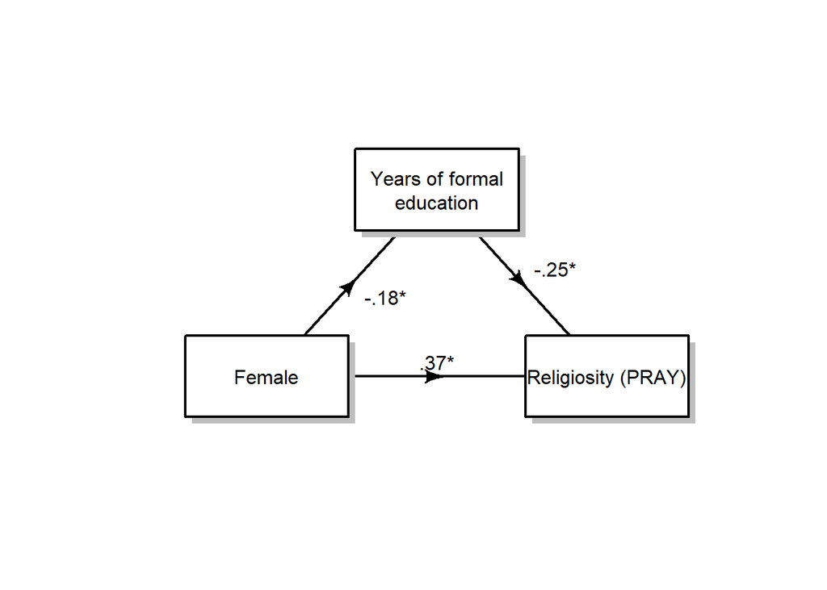

The direct effect has decreased slightly, and there is a ‘significant’ indirect effect. This is a partial mediation. Does model comparison capture this?

```
##                WAIC    SE
## m2.1        4419.15 93.47
## m2.2        4395.03 92.83
## m2.1 - m2.2   24.12 10.36
```

Yes. The mediation model is preferred.

## 2.3. Moderated mediation model

```
##  Family: MV(cumulative, gaussian)
##   Links: mu = logit; disc = identity
##          mu = identity; sigma = identity
## Formula: PRAY ~ 1 + FORMALED.std * MMAT.std + female * MMAT.std + (1 | SITE)
##          FORMALED.std ~ 1 + female + (1 | SITE)
##    Data: d_temp (Number of observations: 1155)
## Samples: 4 chains, each with iter = 2000; warmup = 1000; thin = 1;
##          total post-warmup samples = 4000
##
## Group-Level Effects:
## ~SITE (Number of levels: 9)
##                           Estimate Est.Error l-95% CI u-95% CI Eff.Sample Rhat
## sd(PRAY_Intercept)            1.52      0.61     0.75     3.01       1213 1.00
## sd(FORMALEDstd_Intercept)     1.03      0.33     0.60     1.87       1206 1.00
##
## Population-Level Effects:
##                            Estimate Est.Error l-95% CI u-95% CI Eff.Sample Rhat
## PRAY_Intercept[1]             -3.53      0.59    -4.73    -2.31       1500 1.00
## PRAY_Intercept[2]             -2.78      0.57    -3.97    -1.58       1485 1.00
## PRAY_Intercept[3]             -2.17      0.57    -3.35    -0.98       1480 1.00
## PRAY_Intercept[4]             -0.79      0.57    -1.95     0.36       1487 1.00
## FORMALEDstd_Intercept         -0.03      0.36    -0.74     0.68       1086 1.00
## PRAY_FORMALED.std             -0.23      0.11    -0.43    -0.02       4732 1.00
## PRAY_MMAT.std                 -0.03      0.11    -0.24     0.19       3588 1.00
## PRAY_female                    0.36      0.14     0.09     0.62       5025 1.00
## PRAY_FORMALED.std:MMAT.std     0.11      0.08    -0.06     0.27       4926 1.00
## PRAY_MMAT.std:female          -0.12      0.14    -0.40     0.17       3763 1.00
## FORMALEDstd_female            -0.18      0.04    -0.26    -0.11       5786 1.00
##
## Family Specific Parameters:
##                   Estimate Est.Error l-95% CI u-95% CI Eff.Sample Rhat
## sigma_FORMALEDstd     0.64      0.01     0.62     0.67       5850 1.00
##
## Samples were drawn using sampling(NUTS). For each parameter, Eff.Sample
## is a crude measure of effective sample size, and Rhat is the potential
## scale reduction factor on split chains (at convergence, Rhat = 1).
```

Again the lack of interaction effects suggests that there’s no moderation of material insecurity.

```r
compare_ic(m2.1, m2.2, m2.3, ic = "waic")
```

```
##                WAIC    SE
## m2.1        4419.15 93.47
## m2.2        4395.03 92.83
## m2.3        4397.14 92.83
## m2.1 - m2.2   24.12 10.36
## m2.1 - m2.3   22.01 11.25
## m2.2 - m2.3   -2.11  4.17
```

`m2.3` is slightly worse than the mediation-only model.

# 3. BGRIT

Retain complete cases.

```r
# n = 1171
d_temp <-
  d %>%
  select(SITE, BGRIT, FORMALED.std, female, MMAT.std) %>%
  drop_na()
```

## 3.1. Direct effect only

```
##  Family: MV(cumulative, gaussian)
##   Links: mu = logit; disc = identity
##          mu = identity; sigma = identity
## Formula: BGRIT ~ 1 + female + (1 | SITE)
##          FORMALED.std ~ 1 + (1 | SITE)
##    Data: d_temp (Number of observations: 1171)
## Samples: 4 chains, each with iter = 2000; warmup = 1000; thin = 1;
##          total post-warmup samples = 4000
##
## Group-Level Effects:
## ~SITE (Number of levels: 9)
##                           Estimate Est.Error l-95% CI u-95% CI Eff.Sample Rhat
## sd(BGRIT_Intercept)           1.42      0.47     0.82     2.57       1254 1.00
## sd(FORMALEDstd_Intercept)     1.04      0.32     0.60     1.81       1297 1.00
##
## Population-Level Effects:
##                       Estimate Est.Error l-95% CI u-95% CI Eff.Sample Rhat
## BGRIT_Intercept[1]       -2.22      0.49    -3.21    -1.22       1230 1.00
## BGRIT_Intercept[2]       -0.60      0.49    -1.56     0.40       1225 1.00
## BGRIT_Intercept[3]        0.27      0.49    -0.69     1.26       1225 1.00
## BGRIT_Intercept[4]        1.45      0.49     0.49     2.45       1224 1.00
## FORMALEDstd_Intercept    -0.13      0.36    -0.85     0.60       1145 1.00
## BGRIT_female              0.32      0.11     0.10     0.53       5489 1.00
##
## Family Specific Parameters:
##                   Estimate Est.Error l-95% CI u-95% CI Eff.Sample Rhat
## sigma_FORMALEDstd     0.65      0.01     0.63     0.68       5632 1.00
##
## Samples were drawn using sampling(NUTS). For each parameter, Eff.Sample
## is a crude measure of effective sample size, and Rhat is the potential
## scale reduction factor on split chains (at convergence, Rhat = 1).
```

```
## Using 10 posterior samples for ppc type 'dens_overlay' by default.
```

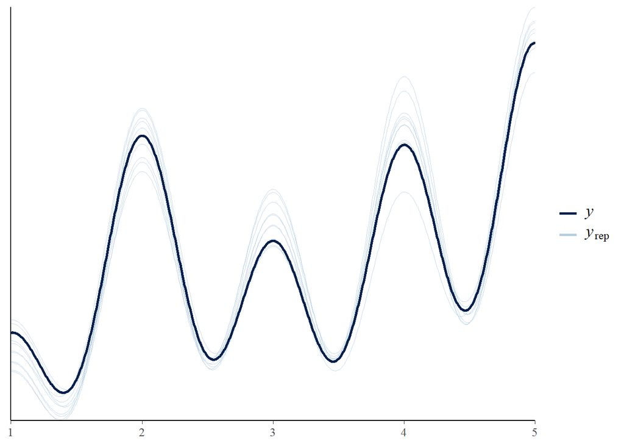

As before, the parameter for `female` lies reliably above zero.

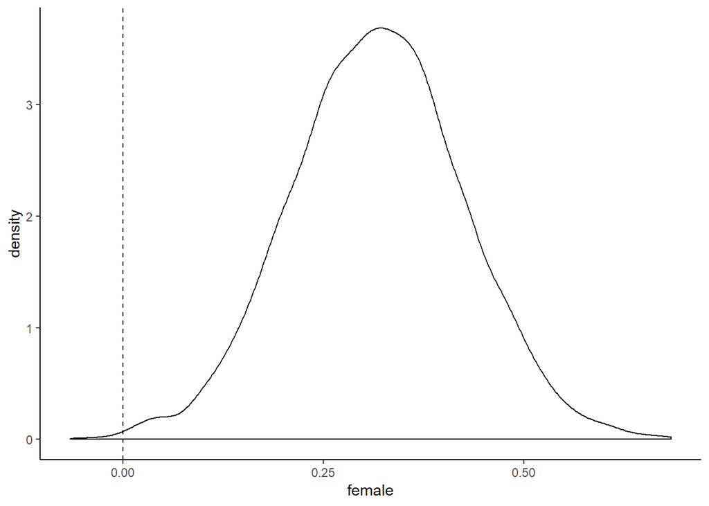

Model comparison (against a null random-intercept-only model) shows that including SEX improves the fit of the model (but again with wide standard errors).

```
##                     WAIC    SE
## m3.1             5688.08 81.15
## m3.1_null        5695.57 80.89
## m3.1 - m3.1_null   -7.48  5.76
```

## 3.2. Mediation model

```
##  Family: MV(cumulative, gaussian)
##   Links: mu = logit; disc = identity
##          mu = identity; sigma = identity
## Formula: BGRIT ~ 1 + female + FORMALED.std + (1 | SITE)
##          FORMALED.std ~ 1 + female + (1 | SITE)
##    Data: d_temp (Number of observations: 1171)
## Samples: 4 chains, each with iter = 2000; warmup = 1000; thin = 1;
##          total post-warmup samples = 4000
##
## Group-Level Effects:
## ~SITE (Number of levels: 9)
##                           Estimate Est.Error l-95% CI u-95% CI Eff.Sample Rhat
## sd(BGRIT_Intercept)           1.55      0.51     0.87     2.81       1201 1.00
## sd(FORMALEDstd_Intercept)     1.02      0.33     0.60     1.82        982 1.00
##
## Population-Level Effects:
##                       Estimate Est.Error l-95% CI u-95% CI Eff.Sample Rhat
## BGRIT_Intercept[1]       -2.22      0.55    -3.31    -1.10       1142 1.01
## BGRIT_Intercept[2]       -0.60      0.54    -1.68     0.51       1117 1.01
## BGRIT_Intercept[3]        0.27      0.54    -0.83     1.40       1117 1.01
## BGRIT_Intercept[4]        1.46      0.55     0.39     2.60       1111 1.01
## FORMALEDstd_Intercept    -0.02      0.35    -0.75     0.69       1074 1.00
## BGRIT_female              0.29      0.11     0.08     0.50       5666 1.00
## BGRIT_FORMALED.std       -0.19      0.08    -0.36    -0.03       5376 1.00
## FORMALEDstd_female       -0.19      0.04    -0.27    -0.12       6026 1.00
##
## Family Specific Parameters:
##                   Estimate Est.Error l-95% CI u-95% CI Eff.Sample Rhat
## sigma_FORMALEDstd     0.65      0.01     0.62     0.67       5718 1.00
##
## Samples were drawn using sampling(NUTS). For each parameter, Eff.Sample
## is a crude measure of effective sample size, and Rhat is the potential
## scale reduction factor on split chains (at convergence, Rhat = 1).
```

In the diagram, stars represent 95% CIs outside zero.

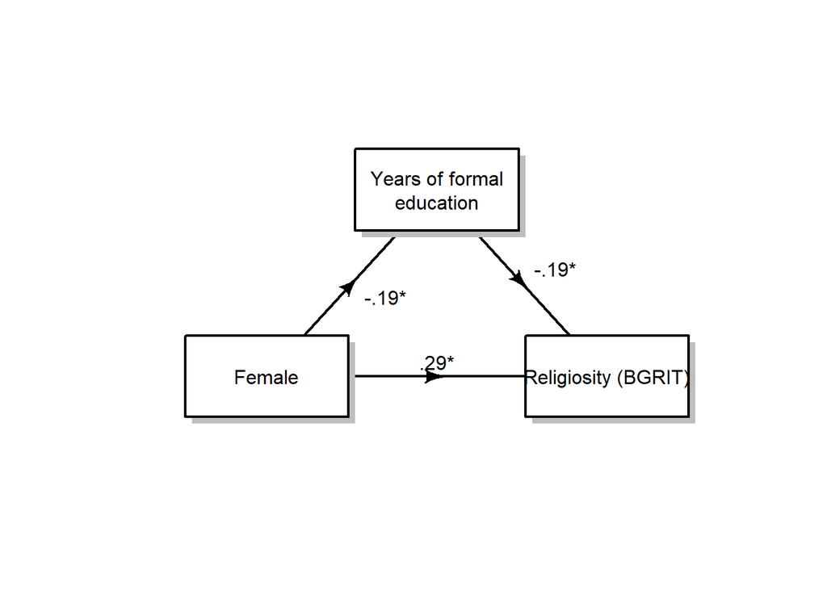

Model comparison.

Another partial mediation. Model comparison captures this.

```
##                WAIC    SE
## m3.1        5688.08 81.15
## m3.2        5661.45 81.15
## m3.1 - m3.2   26.63 10.78
```

## 3.3. Moderated mediation model

```
##  Family: MV(cumulative, gaussian)
##   Links: mu = logit; disc = identity
##          mu = identity; sigma = identity
## Formula: BGRIT ~ 1 + FORMALED.std * MMAT.std + female * MMAT.std + (1 | SITE)
##          FORMALED.std ~ 1 + female + (1 | SITE)
##    Data: d_temp (Number of observations: 1171)
## Samples: 4 chains, each with iter = 2000; warmup = 1000; thin = 1;
##          total post-warmup samples = 4000
##
## Group-Level Effects:
## ~SITE (Number of levels: 9)
##                           Estimate Est.Error l-95% CI u-95% CI Eff.Sample Rhat
## sd(BGRIT_Intercept)           1.47      0.50     0.85     2.71       1133 1.00
## sd(FORMALEDstd_Intercept)     1.02      0.31     0.59     1.77       1310 1.00
##
## Population-Level Effects:
##                             Estimate Est.Error l-95% CI u-95% CI Eff.Sample Rhat
## BGRIT_Intercept[1]             -2.26      0.53    -3.29    -1.19       1392 1.00
## BGRIT_Intercept[2]             -0.63      0.52    -1.69     0.43       1383 1.00
## BGRIT_Intercept[3]              0.25      0.52    -0.81     1.32       1384 1.00
## BGRIT_Intercept[4]              1.45      0.52     0.41     2.52       1384 1.00
## FORMALEDstd_Intercept          -0.00      0.35    -0.74     0.69       1228 1.00
## BGRIT_FORMALED.std             -0.17      0.08    -0.33     0.00       5202 1.00
## BGRIT_MMAT.std                  0.01      0.09    -0.17     0.19       4355 1.00
## BGRIT_female                    0.27      0.11     0.07     0.49       6175 1.00
## BGRIT_FORMALED.std:MMAT.std     0.19      0.06     0.07     0.32       5601 1.00
## BGRIT_MMAT.std:female          -0.12      0.11    -0.33     0.09       3982 1.00
## FORMALEDstd_female             -0.19      0.04    -0.27    -0.12       6134 1.00
##
## Family Specific Parameters:
##                   Estimate Est.Error l-95% CI u-95% CI Eff.Sample Rhat
## sigma_FORMALEDstd     0.65      0.01     0.62     0.67       5862 1.00
##
## Samples were drawn using sampling(NUTS). For each parameter, Eff.Sample
## is a crude measure of effective sample size, and Rhat is the potential
## scale reduction factor on split chains (at convergence, Rhat = 1).
```

Material insecurity seems to affect the “b” path (FORMALED.std -> BGRIT). Let’s visualise this.

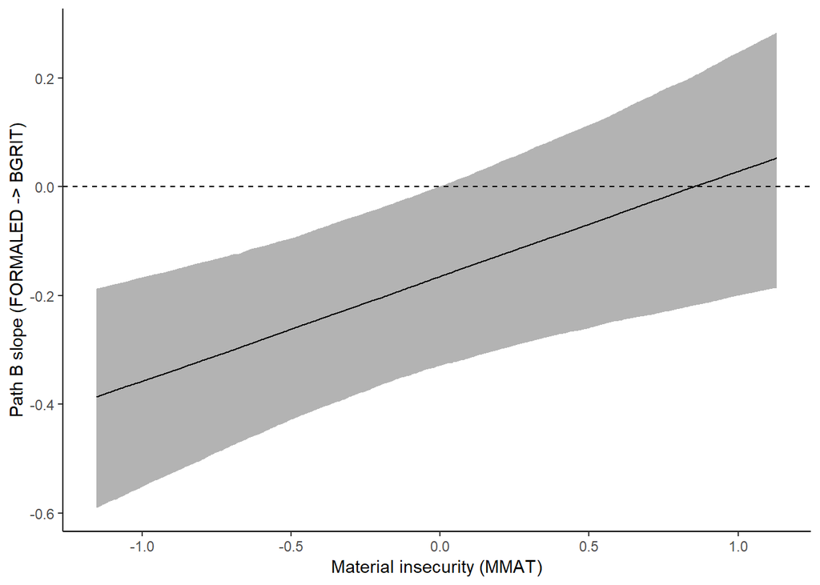

It seems years of formal education has a negative effect on religiosity only for those lower in material insecurity (or lower in material SECURITY? I’m not sure).

This leads to an improvement in model fit, but this isn’t substantial. This suggests there’s a small moderating effect of material insecurity in this model.

```r
compare_ic(m3.1, m3.2, m3.3, ic = "waic")
```

```
##                WAIC    SE
## m3.1        5688.08 81.15
## m3.2        5661.45 81.15
## m3.3        5656.66 81.46
## m3.1 - m3.2   26.63 10.78
## m3.1 - m3.3   31.43 13.62
## m3.2 - m3.3    4.79  7.22
```

# 4. Plotting all model comparisons

It’s useful to visualise all these model comparisons at once. Remember, a lower WAIC is better. Lines represent 95% CIs.

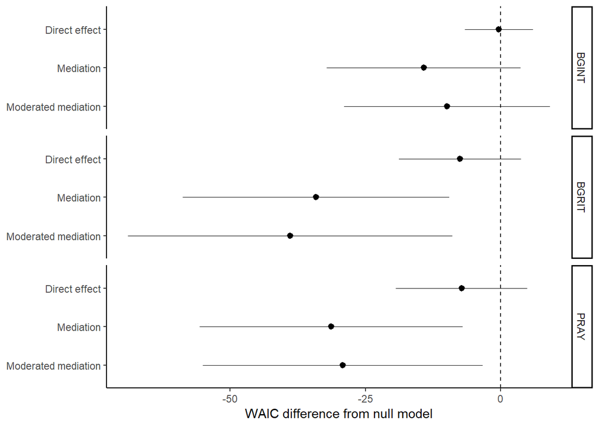